# Illustration

19024

2020-01-02

# 9-20

# Question

1.Go through “R for Beginners” if you are not familiar with R programming.

2.Use knitr to produce at least 3 examples(texts, figures, tables)

# Answer

1.I’m already familiar with R programming and I have read that book before.

2.1 texts

This example computes the mean value and the varianve of 1000 samples. They are simulated using ‘rnorm’ function.

$$\begin{eqnarray*}
n &=& 1000
\\
\overline{X} &=& \frac{1}{n}\sum_{i = 1}^{n}X_i
\\
S_{n-1}^2 &=& \frac{1}{n-1}\sum_{i = 1}^{n}{(X_i - \overline{X})}^2
\end{eqnarray*}$$

```r
x = rnorm(1000) #simulate 100 data
x_mean = mean(x)
x_var = var(x)
text1 = paste('mean:',x_mean, sep = '')
text2 = paste('var:', x_var, sep = '')
print(text1)
```

```
## [1] "mean:-0.0290066166735253"
```

```r
print(text2)
```

```
## [1] "var:1.00481675157269"
```

2.2 figures

$\chi^2_{3}$ ~ $\Gamma(\frac{3}{2},\frac{1}{2})$

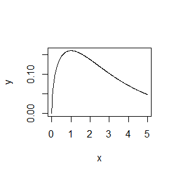

```r
f <- function(x){
  return(2^(-3/2)*pi^(-0.25)*x^0.5*exp(-x/2))
}
x = seq(from=0, to=5, by=0.01) #cut the interval
y = f(x)
plot(x,y,type='l') #plot
```

2.3 table

This is a table of the coefficients in a linear regression.

```r
data('cars') #load dataset
library(knitr)
out = lm(dist~speed,cars)#fit linear model
kable(summary(out)$coefficients)
```

|  | Estimate | Std. Error | t value | Pr(>\|t\|) |
| --- | --- | --- | --- | --- |
| (Intercept) | -17.579095 | 6.7584402 | -2.601058 | 0.0123188 |
| speed | 3.932409 | 0.4155128 | 9.463990 | 0.0000000 |

# 9-30

# Question

3.5 A discrete random variable X has probability mass function

| x | 0 | 1 | 2 | 3 | 4 |
| --- | --- | --- | --- | --- | --- |
| p(x) | 0.1 | 0.2 | 0.2 | 0.2 | 0.3 |

Use the inverse transform method to generate a random sample of size 1000 from the distribution of X. Construct a relative frequency table and compare the empirical with the theoretical probabilities. Repeat using the R sample function.

3.7 Write a function to generate a random sample of size n from the Beta(a, b) distribution by the acceptance-rejection method. Generate a random sample of size 1000 from the Beta(3,2) distribution. Graph the histogram of the sample with the theoretical Beta(3,2) density superimposed.

# Answer

## 3.5

```r
#genereate U(0,1), set seed = 357
set.seed(357)
U = runif(1000)
#inverse tranformation
U_sp = vector(mode='numeric', length=1000)
U_sp[U < 0.1] = 0
U_sp[U < 0.3 & U >= 0.1] = 1
U_sp[U < 0.5 & U >= 0.3] = 2
U_sp[U < 0.7 & U >= 0.5] = 3
U_sp[U >= 0.7] = 4
freq <- table(U_sp)
# add a row of theatrical result
gene_prob = freq/1000
theory_prob = c(0.1,0.2,0.2,0.2,0.3)
tb = rbind(freq,gene_prob, theory_prob)
knitr::kable(tb)
```

|  | 0 | 1 | 2 | 3 | 4 |
| --- | --- | --- | --- | --- | --- |
| freq | 113.000 | 182.000 | 196.000 | 212.000 | 297.000 |
| gene_prob | 0.113 | 0.182 | 0.196 | 0.212 | 0.297 |
| theory_prob | 0.100 | 0.200 | 0.200 | 0.200 | 0.300 |

```r
#generate with Rsample
U_real = sample(c(0,1,2,3,4),replace = T, size = 1000, prob = c(0.1,0.2,0.2,0.2,0.3))
table(U_real) -> freq2
gene_prob2 = freq2/1000
tb2 = rbind(freq2, gene_prob2, theory_prob)
knitr::kable(tb2)
```

|  | 0 | 1 | 2 | 3 | 4 |
| --- | --- | --- | --- | --- | --- |
| freq2 | 102.000 | 229.000 | 174.000 | 185.000 | 310.00 |
| gene_prob2 | 0.102 | 0.229 | 0.174 | 0.185 | 0.31 |
| theory_prob | 0.100 | 0.200 | 0.200 | 0.200 | 0.30 |

## 3.7

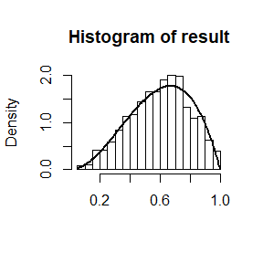

```r
# write a function
BETA <- function(a,b,n){

  #let c = beta(a,b)
  #compute c
  result = vector()
  #generate random variables until we have enough samples(n)
  while(TRUE){
    c = factorial(a+b-1) / factorial(a-1) / factorial(b - 1)
  #generate variables
    len = n*c*2
    U = runif(len)
    G0 = runif(len)
    F0 = c*G0^(a-1)*(1-G0)^(b-1)
    result_temp = G0[(F0) >= c*U]
    result = c(result, result_temp)
    if(length(result)>=n){
      break;
    }
  }
  return(result[1:n])
}

result = BETA(3,2,1000)
#draw the density curve
x = seq(0,1,0.01)
y = (x)^2*(1-x)^1/beta(3,2)
par(new=T)
hist(result, breaks=30,xlab = '', probability = T)
curve(dbeta(x,3,2),add=TRUE, lwd=2)
```

## 3.12

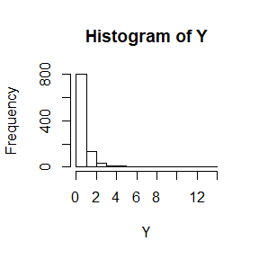

```r
n = 1000 # number of sample
r = 4
beta = 2

Lambda = rgamma(n,r,beta)

Y = rexp(n,Lambda)

hist(Y)
```

# 10-11

# Question

## 5.1

Compute a Monte Carlo estimate of
$$\int_{0}^{\frac{\pi}{3}}sint dt$$
and compare your estimate with the exact value of the integral

## Answer

Firstly, according to calculus, we have
$$\int_{0}^{\frac{\pi}{3}}sint dt = \frac{1}{2}$$
Since $sinx = x + \frac{x^3}{6} + O(x^5)$ So firstly, I use $x - \frac{x^3}{6}$ as the control variate and
$$E[x - \frac{x^3}{6}] = \int_{0}^{\frac{\pi}{3}}(x - \frac{x^3}{6})dx / \frac{\pi}{3} = \frac{\pi}{6} - \frac{\pi^3}{648}$$

```r
library(knitr)
library(ggplot2)
UP = pi/3
U = runif(10000, 0, UP)
G = sin(U)
CONTROL = U - U^3/6
ECONTROL = pi/6 - pi^3/648
L = lm(G ~ CONTROL)
cstar = L$coefficients[2]
G_adjust = G - cstar*(CONTROL - ECONTROL)
result_adj = mean(G_adjust)*UP
result_0 = mean(G)*UP
var_0 = var(G)*UP^2
var_adjust = var(G_adjust)*UP^2
percentage_empirical = 1 - var_adjust/var_0
percentage_theorical = summary(L)$r.squared
result = as.matrix(c(result_0,result_adj))
result = cbind(result,c(sqrt(var_0),sqrt(var_adjust)))
result = cbind(result, c(0.5,0.5))
rownames(result) <- c('unadjust','adjust')
colnames(result) = c('estimate','standard error', 'True')
kable(result)
```

|  | estimate | standard error | True |
| --- | --- | --- | --- |
| unadjust | 0.5018227 | 0.2691152 | 0.5 |
| adjust | 0.5000354 | 0.0017450 | 0.5 |

```r
100*c(percentage_empirical,percentage_theorical) ->tb
names(tb) <-c('empirical', 'theorical')
tb = as.matrix(tb)
colnames(tb) <- c('percentage of variance reduced(control variate)')
kable(tb)
```

|  | percentage of variance reduced(control variate) |
| --- | --- |
| empirical | 99.9958 |
| theorical | 99.9958 |

Secondly, I use importance sampling as a comparision method.

since the graph of sin(x) in the interval[0,$\frac{\pi}{3}$] is like this

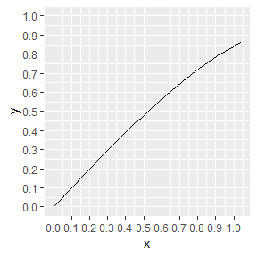

```r
# up is the upper bound(pi/3)
x = seq(0,UP,0.01)
y = sin(x)
data = as.data.frame(cbind(x,y))
g = ggplot(data, aes(x,y))
g + geom_line() + scale_x_continuous(breaks = seq(0,1.5,0.1)) + scale_y_continuous(limits = c(0,1),breaks = seq(0,1.5,0.1))
```

I use random variable X whose pdf likes this
$$f(x) = \frac{xI_{[0,\frac{\pi}{3}]}(x)}{\pi^2/18}$$

These are graphs pdf of X, g(x), and the quotient of g(x) and f(x)

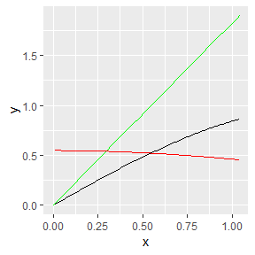

```r
y2 = 18/pi^2*x
y3 = y/y2
data = as.data.frame(cbind(x,y,y2,y3))
g = ggplot(data)
g + geom_line(aes(x,y)) + geom_line(aes(x,y2), color='green')+ geom_line(aes(x,y3), color='red')
```

The function to generate R.V. whose pdf is f(X) and do the importance sampling

```r
rf <- function(n){
  C = pi^2/9
  U = runif(n)
  return(sqrt(U*C))
}
X = rf(10000)
G_imp = sin(X)
f_imp = 18/pi^2*X
result_imp = mean(G_imp/f_imp)
var_imp = var(G_imp/f_imp)
result_imp = as.matrix(c(result_0,result_imp))
result_imp = cbind(result_imp,c(sqrt(var_0),sqrt(var_imp)))
result_imp = cbind(result_imp, c(0.5,0.5))
rownames(result_imp) <- c('unadjust','adjust')
colnames(result_imp) = c('estimate','standard error', 'True')
kable(result_imp)
```

|  | estimate | standard error | True |
| --- | --- | --- | --- |
| unadjust | 0.5018227 | 0.2691152 | 0.5 |
| adjust | 0.5001043 | 0.0274925 | 0.5 |

```r
rm(list = ls())#rmove all the data and variables in this question
```

## Question 5.10

Use Monte Carlo integration with antithetic variables to estimate
$$\int_{0}^{1}{\frac{e^{-x}}{1+x^2}dx}$$
and find the approximate reduction in variance as a percentage of the variance without variance reduction.

## Answer 5.10

I generate X ~ U(0,1), and Y = 1-X, so X and Y are negatively correlated.

```r
X = runif(10000)
Y = 1-X
G1 = exp(-X)/(1+X^2)
G2 = exp(-Y)/(1+Y^2)
G = (G1+G2)/2
X2 = runif(10000)
G3 = exp(-X2)/(1+X2^2)
result_original = c(mean(c(G1,G3)), sd(c(G1,G3)))
result_anti = c(mean(G), sd(G))
result =matrix(c(result_anti,result_original),2,2,byrow = T)
colnames(result) <- c('estimate', 'standard error')
rownames(result) <- c('anti', 'normal')
percentage_reduced = 1-var(G)/var(c(G1,G3))
kable(result)
```

|  | estimate | standard error |
| --- | --- | --- |
| anti | 0.5247972 | 0.0331994 |
| normal | 0.5240195 | 0.2448416 |

```r
print(percentage_reduced)
```

```
## [1] 0.9816139
```

## Question 5.15

Obtain the stratified importance sampling estimate in Example 5.13 and compare it with the result of Example 5.10

## Answer

$$f(x) = \frac{e^{-x}}{1-e^{-1}}$$
$$F(x) = \frac{1-e^{-x}}{1-e^{-1}}$$

```r
#function of cdf X
pdf <- function(x){
  return(exp(-x)/(1-exp(-1)))
}
cdf <- function(x){
  return((1-exp(-x))/(1-exp(-1)))
}
# function to generate random variable X folloing distribution f
rf <- function(n){
  U <- runif(n)
  return(-log(1-(1-exp(-1))*U))
}
# original method
X = rf(10000)
G = exp(-X)/(1+X^2)
f = pdf(X)
result = mean(G/f)
v = var(G/f)
# stratified importance sampling
X0 = rf(20000)
f_s = G_s = list(5)
X_s = list(5)
result_s = var_s = vector(mode = 'numeric',length = 5)
X_s[[1]] = X0[cdf(X0)<=0.2][1:2000]
X_s[[2]] = X0[cdf(X0)>0.2&cdf(X0)<=0.4][1:2000]
X_s[[3]] = X0[cdf(X0)>0.4&cdf(X0)<=0.6][1:2000]
X_s[[4]] = X0[cdf(X0)>0.6&cdf(X0)<=0.8][1:2000]
X_s[[5]] = X0[cdf(X0)>0.8&cdf(X0)<=1][1:2000]
for(i in 1:5){
  G_s[[i]] = exp(-X_s[[i]])/(1+X_s[[i]]^2)
  f_s[[i]] = pdf(X_s[[i]])*5
  result_s[i] = mean(G_s[[i]]/f_s[[i]])
  var_s[i] = var(G_s[[i]]/f_s[[i]])
}
est_s  = sum(result_s)
v_s = sum(var_s)
est_importance = c(result,sqrt(v))
est_stratify_importance = c(est_s,sqrt(v_s))
mt = as.matrix(rbind(est_importance,est_stratify_importance))
colnames(mt) = c('est', 'sd')
kable(mt)
```

|  | est | sd |
| --- | --- | --- |
| est_importance | 0.5255146 | 0.0968406 |
| est_stratify_importance | 0.5251765 | 0.0093139 |

# 10-18

# Question

## 6.5

Suppose a 95% symmetric t-interval is applied to estimate a mean, but the sample data are non-normal. Then the probability that the confidence interval covers the mean is not necessarily equal to 0.95. Use a Monte Carlo experiment to estimate the coverage probability of the t-interval for random samples of $\chi^2(2)$ data with sample size n = 20. Compare your t-interval results with the simulation results in Example 6.4. (The t-interval should be more robust to departures from normality than the interval for variance.)

## 6.6

6.6 Estimate the 0.025, 0.05, 0.95, and 0.975 quantiles of the skewness $\sqrt{b1}$ under normality by a Monte Carlo experiment. Compute the standard error of the estimates from (2.14) using the normal approximation for the density (with exact variance formula). Compare the estimated quantiles with the quantiles of the large sample approximation $\sqrt{b1} \approx$ N(0, 6/n)

# Answer

## 6.5

```r
set.seed(4257)
library(ggplot2)
# get 1000 times of Chisq2(2) Sample and compute the confidence interval
generate = function(n, alpha){
  X = rchisq(n,2)
  B = abs(sqrt(var(X)/n)*qt(1-alpha/2, df=n-1))
  return(c(mean(X)-B,mean(X)+B))
}
RESULT = replicate(1000, expr = generate(20,0.05))
REALmean = 2
temp1 = RESULT[1,]<2
temp2 = RESULT[2,]>2
Proportion = sum(temp1&temp2)/1000 * 100# the proportion that confidence interval contains the real mean
knitr::kable(Proportion)
```

| x |
| --- |
| 91.7 |

```r
#this is the graph
```

So the proportion that estimates are contained by the CI is about $91.7 \%$

Comparing with example 6.4 and 6.6, the confidence interval of $\overline{X}$ is more robust than the confidence interval of $\sigma^2$

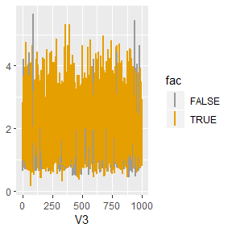

```r
data_0 = as.data.frame(cbind(t(RESULT),1:1000))
data_0$fac = as.factor(temp1&temp2)
ggplot(data_0) + geom_linerange(aes(x=V3, ymin=V1,ymax = V2,color=fac),size = 1) + scale_color_manual(values=c("#999999", "#E69F00"))
```

## 6.6

```r
getskewness = function(N){
  #N is the sample size of the N(0,1) distribution
  X = rnorm(N)
  m = mean(X)
  A = sum((X - m)^3)/N
  B = (sum((X-m)^2)/N)^1.5
  return (A/B)
}
n = 2000
m = 10000
#generate the samples
Y = replicate(m, expr = getskewness(n))
# f(x) in F(x) = p, using normal distribution as an approximation
sigma = 6*(n-2)/(n+1)/(n+3)
p = c(0.025,0.05,0.95,0.975)
Z = sort(Y)
place_est = Z[p*m]
density_est = dnorm(place_est, 0, sqrt(sigma))
place_sd = sqrt(p*(1-p)/m/density_est^2)
place_limit = qnorm(p,0,sqrt(6/n))
#draw the table
result = rbind(place_est,place_limit,place_sd)
colnames(result) = c('0.025','0.05','0.95','0.975')
rownames(result) = c('Monte Carlo estimation', 'Limit estimation','se for Monte Carlo estimation' )
knitr::kable(result)
```

|  | 0.025 | 0.05 | 0.95 | 0.975 |
| --- | --- | --- | --- | --- |
| Monte Carlo estimation | -0.1074956 | -0.0884581 | 0.0895816 | 0.1054445 |
| Limit estimation | -0.1073516 | -0.0900923 | 0.0900923 | 0.1073516 |
| se for Monte Carlo estimation | 0.0014770 | 0.0011052 | 0.0011427 | 0.0013730 |

The estimating result is close to the limit situation.

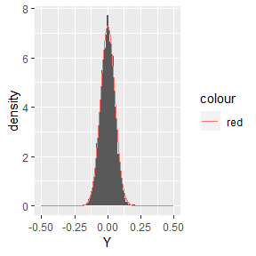

```r
data0 = as.data.frame(Y)
X = seq(-0.5,0.5,0.001)
N_X = dnorm(X,0,sqrt(6/n))
data1 = as.data.frame(cbind(X,N_X))
ggplot() + geom_histogram(data = data0,mapping = aes(x = Y,y=..density..),bins = 100) + geom_line(data = data1, aes(X,N_X, color = 'red'))
```

# 11-1

## Question 6.7

Estimate the power of the skewness test of normality against symmetric Beta$(\alpha, \alpha)$ distributions and comment on the results. Are the results different for heavy-tailed symmetric alternatives such as $t(\mu)$?

## Answer 6.7

# It seems that there are two different understandings for this question(simple Beta distribution and the mixture distribution), so I answer the questions in different understandings seperately.

# Pure beta distribution

Firstly, I write a function to simulate the power given the parameter $\alpha$. I use a sample size n = 100, time of replicates m = 10000 and set the threshold to 0.05.

```r
library(ggplot2)
#cunction to compute skewness
  skew <- function(X){
    M = mean(X)
    m3 <- mean((X - M)^3)
    m2 <- mean((X - M)^2)
    return(m3/m2^1.5)
  }
#beta distribution
POW <- function(alpha){
  m = 10000
  n = 100
  threshold = 0.05
  DATA = list()
  SK = numeric(m)
  cv = qnorm(1-threshold/2, 0, sqrt(6*(n-2)/(n+1)/(n+3)))
  for(i in 1:m){
    DATA[[i]] = rbeta(n,alpha,alpha)
  }
  SK = sapply(DATA, skew)
  return(list(sum(abs(SK)>=cv)/m,SK))
}
#t distribution
POW2 <- function(miu){
  m = 10000
  n = 100
  threshold = 0.05
  DATA = list()
  SK = numeric(m)
  cv = qnorm(1-threshold/2, 0, sqrt(6*(n-2)/(n+1)/(n+3)))
  for(i in 1:m){
    DATA[[i]] = rt(n,miu)
  }
  SK = sapply(DATA, skew)
  return(list(sum(abs(SK)>=cv)/m,SK))
}
#normal distribution
POW_N <- function(){
  m = 10000
  n = 100
  threshold = 0.05
  DATA = list()
  SK = numeric(m)
  cv = qnorm(1-threshold/2, 0, sqrt(6*(n-2)/(n+1)/(n+3)))
  for(i in 1:m){
    DATA[[i]] = rnorm(n)
  }
  SK = sapply(DATA, skew)
  return(list(sum(abs(SK)>=cv)/m,SK))
}
```

for alpha = 1,10,20 compute the power;for miu = 2,5,10,compute the power

```r
p = numeric(6)
p[1] = POW(1)[[1]]
p[2] = POW(10)[[1]]
p[3] = POW(20)[[1]]
p[4] = POW2(2)[[1]]
p[5] = POW2(5)[[1]]
p[6] = POW2(10)[[1]]
names(p) = c('beta1','beta10','beta20','t2','t5','t10')
knitr::kable(p)
```

|  | x |
| --- | --- |
| beta1 | 0.0016 |
| beta10 | 0.0242 |
| beta20 | 0.0300 |
| t2 | 0.8128 |
| t5 | 0.4034 |
| t10 | 0.1995 |

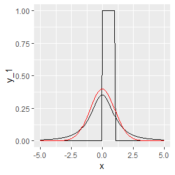

```r
#plot the density of normal,beta,t distribution
x = seq(-5,5,0.05)
y_norm = dnorm(x)
y_1 = dbeta(x,1,1)
y_2 = dbeta(x,10,10)
y_3 = dbeta(x,20,20)
y_4 = dt(x,2)
y_5 = dt(x,5)
y_6 = dt(x,10)
DT = as.data.frame(cbind(x,y_norm,y_1,y_2,y_3,y_4,y_5,y_6))
ggplot(data=DT) + geom_line(mapping = aes(x,y_1))+ geom_line(mapping = aes(x,y_4)) + geom_line(aes(x,y_norm),color='red')
```

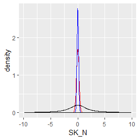

```r
SK_N = POW_N()[[2]]
SK_beta_1 = POW(1)[[2]]
SK_t_2 = POW2(2)[[2]]
SK = as.data.frame(cbind(SK_N,SK_t_2,SK_beta_1))

ggplot(data = SK) + geom_density(mapping = aes(x=SK_N),color='red')+ geom_density(mapping = aes(x=SK_beta_1),color='blue')+ geom_density(mapping = aes(x=SK_t_2))
```

we can see that for the heavy tail distribution like t-distribution, the power of skewness test is bigger since the skewness of it has higher variance. For distributions like beta(1,1), the variance of its skewness is very small, thus it’s hard to reject the hypothesis. For example, the emprical variance of skewness of beta(1,1) is 0.0212 while the theorical variance should be 0.0560(normal situation). as a contrast, the emprical variance of skewness of $t_2$ is 9.4397, which is much higher than the theorical result.

# Mixture of Beta distribution and normal distribution

```r
#p is the probility of the beta distribution or t distribution
POW2_1 <- function(alpha,p){
  m = 10000
  n = 100
  threshold = 0.05
  DATA = list()
  SK = numeric(m)
  cv = qnorm(1-threshold/2, 0, sqrt(6*(n-2)/(n+1)/(n+3)))
  for(i in 1:m){
    flag = sample(c(0,1),replace=TRUE,size=n,prob = c(1-p,p))
    DATA[[i]] = rbeta(n,alpha,alpha)*flag + rnorm(n)*(1-flag)
  }
  SK = sapply(DATA, skew)
  return(list(sum(abs(SK)>=cv)/m,SK))
}
POW2_2 <- function(miu,p){
  m = 10000
  n = 100
  threshold = 0.05
  DATA = list()
  SK = numeric(m)
  cv = qnorm(1-threshold/2, 0, sqrt(6*(n-2)/(n+1)/(n+3)))
  for(i in 1:m){
    flag = sample(c(0,1),replace=TRUE,size=n,prob = c(1-p,p))
    DATA[[i]] = rt(n,miu)*flag + rnorm(n)*(1-flag)
  }
  SK = sapply(DATA, skew)
  return(list(sum(abs(SK)>=cv)/m,SK))
}
#p=0.01,0.1,0.5
#alpha = 1,10
#miu = 2,5
result = list()
result[[1]] = c(POW2_1(1,0.01)[[1]],POW2_1(10,0.01)[[1]],POW2_2(2,0.01)[[1]],POW2_2(5,0.01)[[1]])
result[[2]] = c(POW2_1(1,0.1)[[1]],POW2_1(10,0.1)[[1]],POW2_2(2,0.1)[[1]],POW2_2(5,0.1)[[1]])
result[[3]] = c(POW2_1(1,0.5)[[1]],POW2_1(10,0.5)[[1]],POW2_2(2,0.5)[[1]],POW2_2(5,0.5)[[1]])
names(result) = c('proportion-0.01','proportion-0.1','proportion-0.5')
r = as.data.frame(result)
rownames(r) = c('alpha1','alpha10','miu2','miu5')
knitr::kable(r)
```

|  | proportion.0.01 | proportion.0.1 | proportion.0.5 |
| --- | --- | --- | --- |
| alpha1 | 0.0572 | 0.0985 | 0.7596 |
| alpha10 | 0.0494 | 0.1128 | 0.8279 |
| miu2 | 0.1043 | 0.4241 | 0.7777 |
| miu5 | 0.0593 | 0.1374 | 0.3262 |

## Question 6.A

Use Monte Carlo simulation to investigate whether the empirical Type I error rate of the t-test is approximately equal to the nominal significance level α, when the sampled population is non-normal. The t-test is robust to mild departures from normality. Discuss the simulation results for the cases where the sampled population is (i) $\chi^2(1)$, (ii) Uniform(0,2), and (iii) Exponential(rate=1). In each case, test H0 : $\mu = \mu0$ vs H0 : $\mu = \mu_0$, where $\mu_0$ is the mean of $\chi^2(1)$, Uniform(0,2), and Exponential(1), respectively.

## Answer 6.A

According to Calculus, the mean of $\chi^2_1$ distribution is 1; the mean of $Uniform(0,2)$ distribution is 1; the mean of $Exp(1)$ distribution is 1.

```r
n = 20
Data1 = numeric(10000)
Data2 = numeric(10000)
Data3 = numeric(10000)
Data4 = numeric(10000)
for(i in 1:10000){
Data1[i] = t.test(rchisq(n,1),mu=1,alternative = 'two.sided')$p.value
Data2[i] = t.test(runif(n,0,2),mu=1,alternative = 'two.sided')$p.value
Data3[i] = t.test(rexp(n,1),mu=1,alternative = 'two.sided')$p.value
Data4[i] = t.test(rnorm(n,1,1),mu=1,alternative = 'two.sided')$p.value
}
p1 = sum(abs(Data1)<0.05)/10000
p2 = sum(abs(Data2)<0.05)/10000
p3 = sum(abs(Data3)<0.05)/10000
p4 = sum(abs(Data4)<0.05)/10000
result = c(p1,p2,p3,p4)
names(result) = c('Chi1','U02','exp1','norm1')
knitr::kable(result)
```

|  | x |
| --- | --- |
| Chi1 | 0.1024 |
| U02 | 0.0524 |
| exp1 | 0.0824 |
| norm1 | 0.0487 |

```r
#y1 = t.test(X1, )
```

## Discussion

If we obtain the powers for two methods under a particularsimulation setting with 10,000 experiments: say, 0.651 for onemethod and 0.676 for another method. Can we say the powersare different at 0.05 level?

## Answer

1. The corresponding hypothesis test problem is: $H_0$: method 1 has the same power as method2. $H_1$: the powers of method 1 and method 2 are different.
2. I think we should use paired-t test. Because firstly, there is no evidence showing that the variance of the power of two methods are the same, which makes it questionable to use Z-test. Secondly, since the sample of two methods are not independent(both of them use the same data in one time), we can not use two-sample t test as well. Also, we have quantitative samples, which are not suitable for Mcnemar test.But for paired-t test, we can compare the power of two methods in each simulation and find out whether there are significant difference.
3. To test my hypothesis, I need several repeatment of the process that estimate the empirical power. And in order to make the paired-t test reasonable, I need to know whether the difference of the two methods follows normal distribution.

# 11-8

# Question7.6

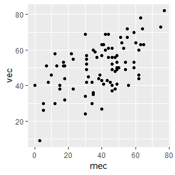

```r
library(ggplot2)
library(bootstrap)
library(corrplot)
data(scor)
ggplot(data=scor,mapping = aes(x=mec,y=vec))+geom_point()
```

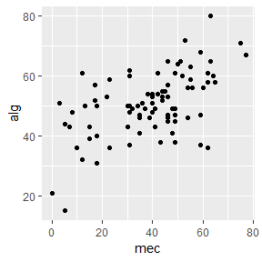

```r
ggplot(data=scor,mapping = aes(x=mec,y=alg))+geom_point()
```

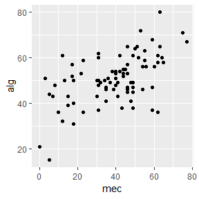

```r
ggplot(data=scor,mapping = aes(x=mec,y=alg))+geom_point()
```

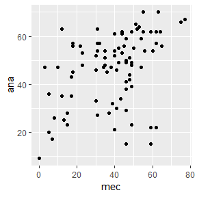

```r
ggplot(data=scor,mapping = aes(x=mec,y=ana))+geom_point()
```

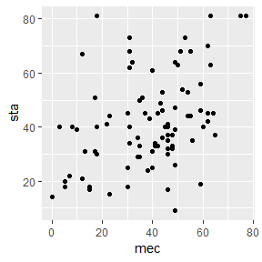

```r
ggplot(data=scor,mapping = aes(x=mec,y=sta))+geom_point()
```

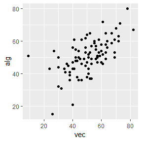

```r
ggplot(data=scor,mapping = aes(x=vec,y=alg))+geom_point()
```

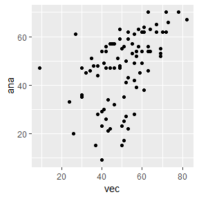

```r
ggplot(data=scor,mapping = aes(x=vec,y=ana))+geom_point()
```

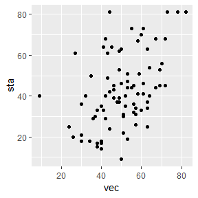

```r
ggplot(data=scor,mapping = aes(x=vec,y=sta))+geom_point()
```

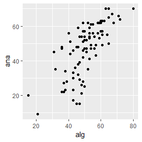

```r
ggplot(data=scor,mapping = aes(x=alg,y=ana))+geom_point()
```

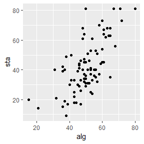

```r
ggplot(data=scor,mapping = aes(x=alg,y=sta))+geom_point()
```

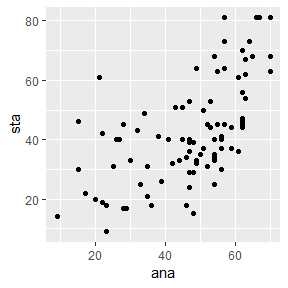

```r
ggplot(data=scor,mapping = aes(x=ana,y=sta))+geom_point()
```

```r
knitr::kable(cor(scor))
```

|  | mec | vec | alg | ana | sta |
| --- | --- | --- | --- | --- | --- |
| mec | 1.0000000 | 0.5534052 | 0.5467511 | 0.4093920 | 0.3890993 |
| vec | 0.5534052 | 1.0000000 | 0.6096447 | 0.4850813 | 0.4364487 |
| alg | 0.5467511 | 0.6096447 | 1.0000000 | 0.7108059 | 0.6647357 |
| ana | 0.4093920 | 0.4850813 | 0.7108059 | 1.0000000 | 0.6071743 |
| sta | 0.3890993 | 0.4364487 | 0.6647357 | 0.6071743 | 1.0000000 |

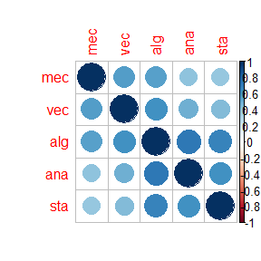

```r
corrplot(cor(scor))
```

```r
#bootstrap
library(boot)
r_12 = function(x,i){
  return(cor(x$mec[i],x$vec[i]))
}
r_34 = function(x,i){
  return(cor(x$alg[i],x$ana[i]))
}
r_35 = function(x,i){
  return(cor(x$alg[i],x$sta[i]))
}
r_45 = function(x,i){
  return(cor(x$ana[i],x$sta[i]))
}
result_12 = boot(scor,r_12,1000)
result_34 = boot(scor,r_34,1000)
result_35 = boot(scor,r_35,1000)
result_45 = boot(scor,r_45,1000)
result = c(sd(result_12$t),sd(result_34$t),sd(result_35$t),sd(result_45$t))
names(result) = c('12','34','35','45')
knitr::kable(result)
```

|  | x |
| --- | --- |
| 12 | 0.0779569 |
| 34 | 0.0486264 |
| 35 | 0.0593826 |
| 45 | 0.0690917 |

# Project 7.B

Repeat Project 7.A for the sample skewness statistic. Compare the coverage rates for normal populations (skewness 0) and $\chi_2(5)$ distributions (positive skewness).

# Answer

```r
data_norm = matrix(rnorm(50*500),ncol=50,nrow=500)
data_chisq = matrix(rchisq(50*500,5),ncol=50,nrow=500)
interval_norm = list()
interval_chisq = list()
SK = function(x,i){
  EX = mean(x[i])
  EX2 = sum((x[i] - EX)^2)/length(i)
  EX3 = sum((x[i] - EX)^3)/length(i)
  return(EX3/EX2^1.5)
}
#do the boostrap to estimate sd.
for(i in 1:500){
  bnorm = boot(data_norm[i,],SK,500)
  bchisq = boot(data_chisq[i,],SK,500)
  interval_norm[[i]] = c(boot.ci(bnorm,conf = 0.95,type = 'norm'),boot.ci(bnorm,conf = 0.95,type = 'basic'),boot.ci(bnorm,conf = 0.95,type = 'perc'))
    interval_chisq[[i]] = c(boot.ci(bchisq,conf = 0.95,type = 'norm'),boot.ci(bchisq,conf = 0.95,type = 'basic'),boot.ci(bchisq,conf = 0.95,type = 'perc'))
}
real_norm = 0
real_chisq = sqrt(8/5)
# two functions that compute the samples in the intervals and fall in the left/right of the interval
get_in_norm = function(x){
  in_normal = (x$normal[2]<0)&(x$normal[3]>0)
  left_normal = x$normal[2]>0
  right_normal = x$normal[3]<0
  in_basic = (x$basic[4]<0)&(x$basic[5]>0)
  left_basic = x$basic[4]>0
  right_basic = x$basic[5]<0
  in_perc = (x$perc[4]<0)&(x$perc[5]>0)
  left_perc = x$perc[4]>0
  right_perc = x$perc[5]<0
  return(c(in_normal,left_normal, right_normal,in_basic,left_basic,right_basic,in_perc,left_perc,right_perc))
}
get_in_chisq = function(x){
  in_normal = (x$normal[2]<real_chisq)&(x$normal[3]>real_chisq)
  left_normal = x$normal[2]>real_chisq
  right_normal = x$normal[3]<real_chisq
  in_basic = (x$basic[4]<real_chisq)&(x$basic[5]>real_chisq)
  left_basic = x$basic[4]>real_chisq
  right_basic = x$basic[5]<real_chisq
  in_perc = (x$perc[4]<real_chisq)&(x$perc[5]>real_chisq)
  left_perc = x$perc[4]>real_chisq
  right_perc = x$perc[5]<real_chisq
  return(c(in_normal,left_normal, right_normal,in_basic,left_basic,right_basic,in_perc,left_perc,right_perc))
}
percent_normal = sapply(interval_norm, get_in_norm)
percent_chisq = sapply(interval_chisq, get_in_chisq)
result = matrix(ncol = 9,nrow = 2)
for(i in 1:9){
  result[1,i] = mean(percent_normal[i,])
  result[2,i] = mean(percent_chisq[i,])
}
colnames(result) = c('in_normal','left_normal','right_normal',
   'in_basic','left_basic','right_basic',
   'in_perc','left_perc','right_perc')
rownames(result) = c('norm','chisq5')
knitr::kable(result)
```

|  | in_normal | left_normal | right_normal | in_basic | left_basic | right_basic | in_perc | left_perc | right_perc |
| --- | --- | --- | --- | --- | --- | --- | --- | --- | --- |
| norm | 0.894 | 0.052 | 0.054 | 0.886 | 0.052 | 0.062 | 0.942 | 0.032 | 0.026 |
| chisq5 | 0.756 | 0.028 | 0.216 | 0.722 | 0.050 | 0.228 | 0.748 | 0.000 | 0.252 |

Comparing the results of $\chi_2(5)$ and normal distribution, we can find that in normal distribution, the proportion of samples that estimated interval contains true values is higher than $\chi_2(5)$. Also, fot $\chi_2(5)$ distribution, most of the intervals that don’t contains true value fall into the right of the interval.

# 11-15

# Question7.8

Refer to Exercise 7.7. Obtain the jackknife estimates of bias and standard error of $\hat{\theta}$

# Answer 7.8

```r
library(bootstrap)
library(boot)
data(scor)
Length = nrow(scor)
#compute the estiate theta-hat.since cov function in R have been adjusted, I use (n-1)/n*cov as the MLE of covariance matrix estimation
Sigma_hat = cov(scor)*(Length-1)/Length
EIGEN = eigen(Sigma_hat)
theta_hat = EIGEN$values[1]/sum(EIGEN$values)
#do the jacknife
JACK = vector(length=Length)
for(i in 1:Length){
  Sigma_hat = cov(scor[-i,])*(Length-2)/(Length-1)
  EIGEN = eigen(Sigma_hat)
  JACK[i] = EIGEN$values[1]/sum(EIGEN$values)
}
BIAS = (mean(JACK)-theta_hat)*(Length-1)
SE = sqrt((Length-1)/(Length)*sum((JACK-mean(JACK))^2))
##########################################################
#Another solution using jacknife function in boot package
SCOR = as.matrix(scor)
est = function(X){
  Sigma_hat = cov(SCOR[X,])*(Length-2)/(Length-1)
  EIGEN = eigen(Sigma_hat)
  return = EIGEN$values[1]/sum(EIGEN$values)
}
RESULT = jackknife(1:Length,est)

##########################################################

result = c(theta_hat,BIAS,SE)
names(result) = c('theta_hat','BIAS','SE')
knitr::kable(result)
```

|  | x |
| --- | --- |
| theta_hat | 0.6191150 |
| BIAS | 0.0010691 |
| SE | 0.0495523 |

# Question 7.10

In Example 7.18, leave-one-out (n-fold) cross validation was used to select the best fitting model. Repeat the analysis replacing the Log-Log model with a cubic polynomial model. Which of the four models is selected by the cross validation procedure? Which model is selected according to maximum adjusted $R^2$?

# Answer

```r
library(DAAG)
attach(ironslag)
L10 <- lm(magnetic ~ chemical)
L20 <- lm(magnetic ~ chemical + I(chemical^2))
L30 <- lm(log(magnetic) ~ chemical)
L40 <- lm(magnetic ~ chemical + I(chemical^2) + I(chemical^3))
Length = nrow(ironslag)
result = matrix(ncol = 4,nrow = Length)
for(i in 1:Length){
  mag = magnetic[-i]
  chem = chemical[-i]
  L1 <- lm(mag ~ chem)
  L2 <- lm(mag ~ chem + I(chem^2))
  L3 <- lm(log(mag) ~ chem)
  L4 <- lm(mag ~ chem + I(chem^2) + I(chem^3))
  result[i,1] = magnetic[i] - predict(L1,data.frame(chem=chemical[i]))
  result[i,2] = magnetic[i] - predict(L2,data.frame(chem=chemical[i]))
  result[i,3] = magnetic[i] - exp(predict(L3,data.frame(chem=chemical[i])))
  result[i,4] = magnetic[i] - predict(L4,data.frame(chem=chemical[i]))
}
CR = c(mean(result[,1]^2),mean(result[,2]^2),mean(result[,3]^2),mean(result[,4]^2))
R_square = c(summary(L10)$adj.r.squared,summary(L20)$adj.r.squared,summary(L30)$adj.r.squared,summary(L40)$adj.r.squared)
names(CR) = c('LM','quadratic','exp','cubic')
names(R_square) = c('LM','quadratic','exp','cubic')
```

According to the errors below, we should choose model 2 (quadratic model)

```r
knitr::kable(CR)
```

|  | x |
| --- | --- |
| LM | 19.55644 |
| quadratic | 17.85248 |
| exp | 18.44188 |
| cubic | 18.17756 |

According to the adjusted-R square below, we should also choose model 2(quadratic model)

```r
knitr::kable(R_square)
```

|  | x |
| --- | --- |
| LM | 0.5281545 |
| quadratic | 0.5768151 |
| exp | 0.5280556 |
| cubic | 0.5740396 |

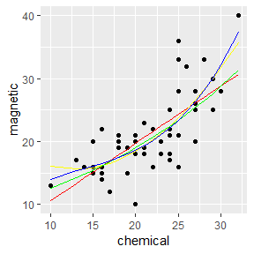

```r
library(ggplot2)
MYdata = ironslag
MYdata$L1 = L10$fitted.values
MYdata$L2 = L20$fitted.values
MYdata$L3 = L30$fitted.values
MYdata$L4 = L40$fitted.values
ggplot(data = MYdata)+geom_point(mapping = aes(x=chemical,y=magnetic)) + geom_line(mapping = aes(x=chemical,y=L1),color='red')+geom_line(mapping = aes(x=chemical,y=L2),color='yellow')+geom_line(mapping = aes(x=chemical,y=exp(L3)),color='green')+geom_line(mapping = aes(x=chemical,y=L4),color='blue')
```

#11-22

# QUESTION 8.3

The Count 5 test for equal variances in Section 6.4 is based on the maximum number of extreme points. Example 6.15 shows that the Count 5 criterion is not applicable for unequal sample sizes. Implement a permutation test for equal variance based on the maximum number of extreme points that applies when sample sizes are not necessarily equal.

# Answer 8.3

Suppose that we have $H_0: \sigma_1^2 = \sigma_2^2$, then the count5 statistisc should have same distribution after permutation, so I compute the proportion of count5 of permutations that have more extreme values than the true value

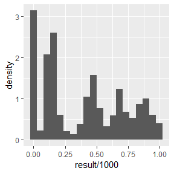

```r
library(ggplot2)
n1 = 20
n2 = 30
m = 1000
result = replicate(m, expr={
  X = rnorm(n1)
  Y = rnorm(n2)
  L = c(X,Y)
  x = X-mean(X)
  y = Y-mean(Y)
  L = c(x,y)
  count5 = max(sum(x > max(y)) + sum(x < min(y)),sum(y > max(x)) + sum(y < min(x)))
  temp = numeric(length = 999)
  for (i in 1:999){
    permu = sample(1:(n1+n2),n1+n2)
    X2 = L[permu[1:n1]]
    Y2 = L[permu[(n1+1):(n1+n2)]]
    x = X2 - mean(X2)
    y = Y2 - mean(Y2)
    temp[i] = max(sum(x > max(y)) + sum(x < min(y)),sum(y > max(x)) + sum(y < min(x)))
  }
  sum(count5>temp)
})
pt = as.data.frame(result/1000)
ggplot(data = pt)+geom_histogram(mapping = aes(result/1000,..density..),bins = 20)
```

```r
print(sum(pt<=0.95))
```

```
## [1] 968
```

# Question 2

Power comparison (distance correlation test versus ballcovariance test) Model 1:Y=X/4+e Model 2:Y=X/4*e #Answer

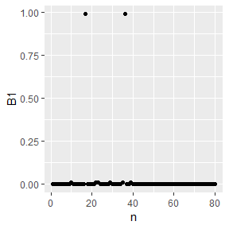

```r
library(MASS)
library(Ball)
library(energy)
library(boot)
library(ggplot2)
N = 100
getpower = function(N){
POWER = matrix(0,ncol = 4,nrow = 100)
  for(i in 1:100){
X = mvrnorm(N,c(0,0),matrix(c(1,0,0,1),nrow=2,byrow = T))
E = mvrnorm(N,c(0,0),matrix(c(1,0,0,1),nrow=2,byrow = T))
Y1 = X/4+E
Y2 = X/4*E
POWER[i,1] = bcov.test(X,Y1,R=999)$p.value
POWER[i,2] = bcov.test(X,Y2,R=999)$p.value
POWER[i,3] = dcor.test(X,Y1,R=999)$p.value
POWER[i,4] = dcor.test(X,Y2,R=999)$p.value
  }
return (colSums(POWER<0.05)/100)
}
POWER = matrix(0,ncol=4,nrow=80)
for(i in 1:40){
  POWER[i,] = getpower(i)
}
DT = as.data.frame(cbind(1:80,POWER))
colnames(DT) = c('n','B1','B2','D1','D2')
#ball, Y1-X
ggplot(data=DT) + geom_point(mapping = aes(n,B1))
```

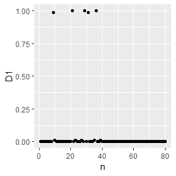

```r
#distance, Y1-X
ggplot(data=DT) + geom_point(mapping = aes(n,D1))
```

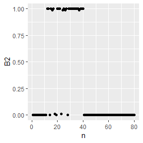

```r
#ball,Y2-X
ggplot(data=DT) + geom_point(mapping = aes(n,B2))
```

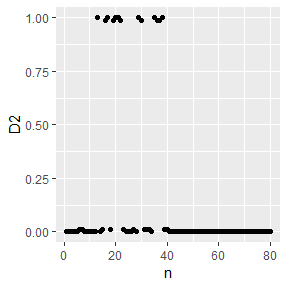

```r
#distance,Y2-x
ggplot(data=DT) + geom_point(mapping = aes(n,D2))
```

# 11-29

## Question 9.4

Implement a random walk Metropolis sampler for generating the standard Laplace distribution (see Exercise 3.2). For the increment, simulate from a normal distribution. Compare the chains generated when different variances are used for the proposal distribution. Also, compute the acceptance rates of each chain

## Answer

Since the Laplace distribution is
$$f(x) = \frac{1}{2\lambda}e^{-\frac{|x-\mu|}{\lambda}}$$

when $\lambda=1$,$\mu=0$, we have
$$f(x)=\frac{e^{-|x|}}{2}$$

So the acceptance rate from $X_t$ to $Y$ is $\frac{f(Y)}{f(X)}$, which equals to
$$e^{-|Y|+|X_t|}$$

# Sigma=1:

```r
library(ggplot2)
sigma = 1
L = 10000
Series = numeric(L)
Uniform = runif(L)
k=0
for (i in 2:L){
  y = rnorm(1,Series[i-1],sigma)
  if(Uniform[i]<=exp(-abs(y)+abs(Series[i-1]))){
    Series[i] = y
    k=k+1
  }
  else{
    Series[i] = Series[i-1]
  }
}
AC_rate = k/L
print(AC_rate)
```

```
## [1] 0.7031
```

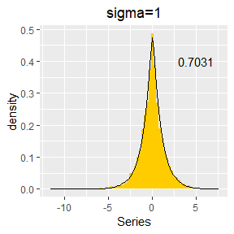

```r
DATA_0 = as.data.frame(cbind(Series,1:L))
LP = function(x){1/2*exp(-abs(x))}
ggplot(data = DATA_0)+geom_histogram(mapping = aes(Series,..density..),bins = 70,fill='#FFCC00')+stat_function(fun=LP)+labs(title = "sigma=1")+theme(plot.title=element_text(hjust=0.5))+annotate(geom = 'text',x=5,y=0.4,label=as.character(AC_rate))
```

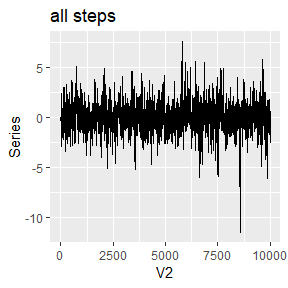

```r
DATA_last = as.data.frame(cbind(Series[9000:10000],9000:10000))
ggplot(data = DATA_0)+geom_line(aes(V2,Series))+labs(title = "all steps")
```

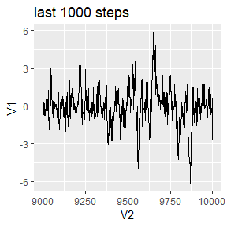

```r
ggplot(data=DATA_last)+geom_line(aes(V2,V1))+labs(title = "last 1000 steps")
```

# sigma=2:

```r
library(ggplot2)
sigma = 2
L = 10000
Series = numeric(L)
Uniform = runif(L)
k=0
for (i in 2:L){
  y = rnorm(1,Series[i-1],sigma)
  if(Uniform[i]<=exp(-abs(y)+abs(Series[i-1]))){
    Series[i] = y
    k=k+1
  }
  else{
    Series[i] = Series[i-1]
  }
}
AC_rate = k/L
print(AC_rate)
```

```
## [1] 0.5254
```

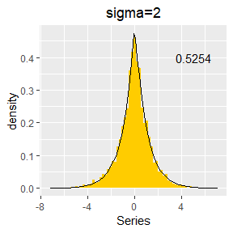

```r
DATA_0 = as.data.frame(cbind(Series,1:L))
LP = function(x){1/2*exp(-abs(x))}
ggplot(data = DATA_0)+geom_histogram(mapping = aes(Series,..density..),bins = 70,fill='#FFCC00')+stat_function(fun=LP)+labs(title = "sigma=2")+theme(plot.title=element_text(hjust=0.5))+annotate(geom = 'text',x=5,y=0.4,label=as.character(AC_rate))
```

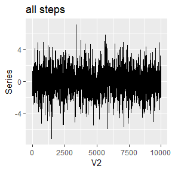

```r
DATA_last = as.data.frame(cbind(Series[9000:10000],9000:10000))
ggplot(data = DATA_0)+geom_line(aes(V2,Series))+labs(title = "all steps")
```

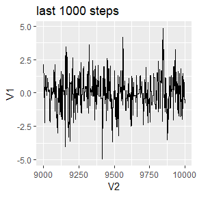

```r
ggplot(data=DATA_last)+geom_line(aes(V2,V1))+labs(title = "last 1000 steps")
```

# sigma=5:

```r
library(ggplot2)
sigma = 5
L = 10000
Series = numeric(L)
Uniform = runif(L)
k=0
for (i in 2:L){
  y = rnorm(1,Series[i-1],sigma)
  if(Uniform[i]<=exp(-abs(y)+abs(Series[i-1]))){
    Series[i] = y
    k=k+1
  }
  else{
    Series[i] = Series[i-1]
  }
}
AC_rate = k/L
print(AC_rate)
```

```
## [1] 0.285
```

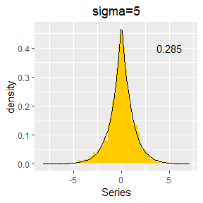

```r
DATA_0 = as.data.frame(cbind(Series,1:L))
LP = function(x){1/2*exp(-abs(x))}
ggplot(data = DATA_0)+geom_histogram(mapping = aes(Series,..density..),bins = 70,fill='#FFCC00')+stat_function(fun=LP)+labs(title = "sigma=5")+theme(plot.title=element_text(hjust=0.5))+annotate(geom = 'text',x=5,y=0.4,label=as.character(AC_rate))
```

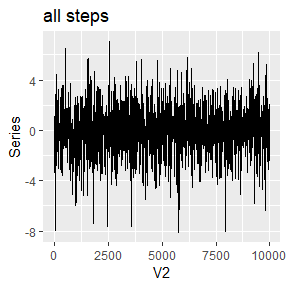

```r
DATA_last = as.data.frame(cbind(Series[9000:10000],9000:10000))
ggplot(data = DATA_0)+geom_line(aes(V2,Series))+labs(title = "all steps")
```

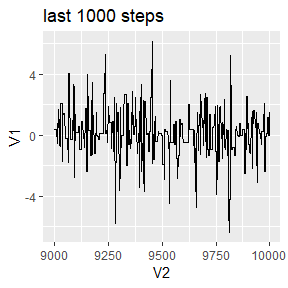

```r
ggplot(data=DATA_last)+geom_line(aes(V2,V1))+labs(title = "last 1000 steps")
```

# sigma=10:

```r
library(ggplot2)
sigma = 10
L = 10000
Series = numeric(L)
Uniform = runif(L)
k=0
for (i in 2:L){
  y = rnorm(1,Series[i-1],sigma)
  if(Uniform[i]<=exp(-abs(y)+abs(Series[i-1]))){
    Series[i] = y
    k=k+1
  }
  else{
    Series[i] = Series[i-1]
  }
}
AC_rate = k/L
print(AC_rate)
```

```
## [1] 0.1596
```

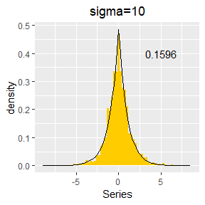

```r
DATA_0 = as.data.frame(cbind(Series,1:L))
LP = function(x){1/2*exp(-abs(x))}
ggplot(data = DATA_0)+geom_histogram(mapping = aes(Series,..density..),bins = 70,fill='#FFCC00')+stat_function(fun=LP)+labs(title = "sigma=10")+theme(plot.title=element_text(hjust=0.5))+annotate(geom = 'text',x=5,y=0.4,label=as.character(AC_rate))
```

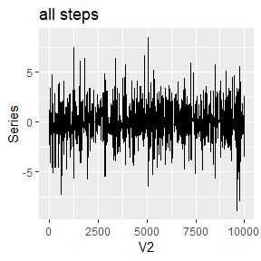

```r
DATA_last = as.data.frame(cbind(Series[9000:10000],9000:10000))
ggplot(data = DATA_0)+geom_line(aes(V2,Series))+labs(title = "all steps")
```

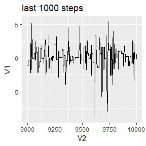

```r
ggplot(data=DATA_last)+geom_line(aes(V2,V1))+labs(title = "last 1000 steps")
```

We can see as the increase of $\sigma$, the acceptance rate becomes lower. Since 0 is the center of Laplace distribution, we can’t see obvious difference of the converge rates.

# 12-06

## Question 9.4

Implement a random walk Metropolis sampler for generating the standard Laplace distribution (see Exercise 3.2). For the increment, simulate from a normal distribution. Compare the chains generated when different variances are used for the proposal distribution. Also, compute the acceptance rates of each chain

## Answer

Since the Laplace distribution is
$$f(x) = \frac{1}{2\lambda}e^{-\frac{|x-\mu|}{\lambda}}$$

when $\lambda=1$,$\mu=0$, we have
$$f(x)=\frac{e^{-|x|}}{2}$$

So the acceptance rate from $X_t$ to $Y$ is $\frac{f(Y)}{f(X)}$, which equals to
$$e^{-|Y|+|X_t|}$$

# Sigma=1:

```r
library(ggplot2)
sigma = 1
L = 10000
Series = numeric(L)
Uniform = runif(L)
k=0
for (i in 2:L){
  y = rnorm(1,Series[i-1],sigma)
  if(Uniform[i]<=exp(-abs(y)+abs(Series[i-1]))){
    Series[i] = y
    k=k+1
  }
  else{
    Series[i] = Series[i-1]
  }
}
AC_rate = k/L
print(AC_rate)
```

```
## [1] 0.7156
```

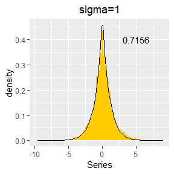

```r
DATA_0 = as.data.frame(cbind(Series,1:L))
LP = function(x){1/2*exp(-abs(x))}
ggplot(data = DATA_0)+geom_histogram(mapping = aes(Series,..density..),bins = 70,fill='#FFCC00')+stat_function(fun=LP)+labs(title = "sigma=1")+theme(plot.title=element_text(hjust=0.5))+annotate(geom = 'text',x=5,y=0.4,label=as.character(AC_rate))
```

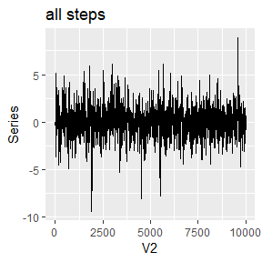

```r
DATA_last = as.data.frame(cbind(Series[9000:10000],9000:10000))
ggplot(data = DATA_0)+geom_line(aes(V2,Series))+labs(title = "all steps")
```

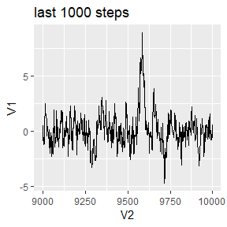

```r
ggplot(data=DATA_last)+geom_line(aes(V2,V1))+labs(title = "last 1000 steps")
```

# sigma=2:

```r
library(ggplot2)
sigma = 2
L = 10000
Series = numeric(L)
Uniform = runif(L)
k=0
for (i in 2:L){
  y = rnorm(1,Series[i-1],sigma)
  if(Uniform[i]<=exp(-abs(y)+abs(Series[i-1]))){
    Series[i] = y
    k=k+1
  }
  else{
    Series[i] = Series[i-1]
  }
}
AC_rate = k/L
print(AC_rate)
```

```
## [1] 0.5337
```

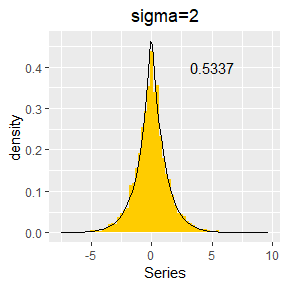

```r
DATA_0 = as.data.frame(cbind(Series,1:L))
LP = function(x){1/2*exp(-abs(x))}
ggplot(data = DATA_0)+geom_histogram(mapping = aes(Series,..density..),bins = 70,fill='#FFCC00')+stat_function(fun=LP)+labs(title = "sigma=2")+theme(plot.title=element_text(hjust=0.5))+annotate(geom = 'text',x=5,y=0.4,label=as.character(AC_rate))
```

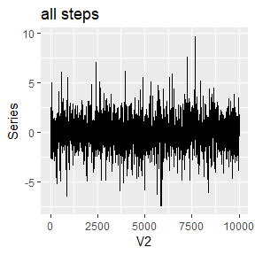

```r
DATA_last = as.data.frame(cbind(Series[9000:10000],9000:10000))
ggplot(data = DATA_0)+geom_line(aes(V2,Series))+labs(title = "all steps")
```

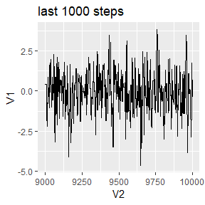

```r
ggplot(data=DATA_last)+geom_line(aes(V2,V1))+labs(title = "last 1000 steps")
```

# sigma=5:

```r
library(ggplot2)
sigma = 5
L = 10000
Series = numeric(L)
Uniform = runif(L)
k=0
for (i in 2:L){
  y = rnorm(1,Series[i-1],sigma)
  if(Uniform[i]<=exp(-abs(y)+abs(Series[i-1]))){
    Series[i] = y
    k=k+1
  }
  else{
    Series[i] = Series[i-1]
  }
}
AC_rate = k/L
print(AC_rate)
```

```
## [1] 0.2832
```

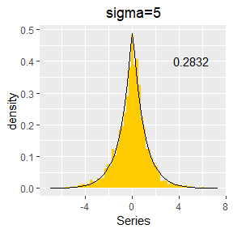

```r
DATA_0 = as.data.frame(cbind(Series,1:L))
LP = function(x){1/2*exp(-abs(x))}
ggplot(data = DATA_0)+geom_histogram(mapping = aes(Series,..density..),bins = 70,fill='#FFCC00')+stat_function(fun=LP)+labs(title = "sigma=5")+theme(plot.title=element_text(hjust=0.5))+annotate(geom = 'text',x=5,y=0.4,label=as.character(AC_rate))
```

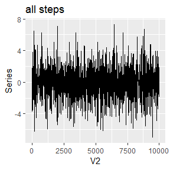

```r
DATA_last = as.data.frame(cbind(Series[9000:10000],9000:10000))
ggplot(data = DATA_0)+geom_line(aes(V2,Series))+labs(title = "all steps")
```

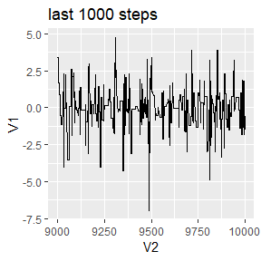

```r
ggplot(data=DATA_last)+geom_line(aes(V2,V1))+labs(title = "last 1000 steps")
```

# sigma=10:

```r
library(ggplot2)
sigma = 10
L = 10000
Series = numeric(L)
Uniform = runif(L)
k=0
for (i in 2:L){
  y = rnorm(1,Series[i-1],sigma)
  if(Uniform[i]<=exp(-abs(y)+abs(Series[i-1]))){
    Series[i] = y
    k=k+1
  }
  else{
    Series[i] = Series[i-1]
  }
}
AC_rate = k/L
print(AC_rate)
```

```
## [1] 0.1616
```

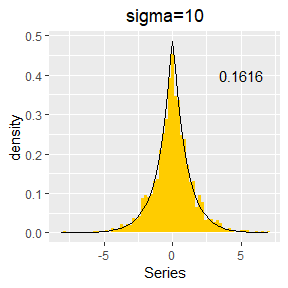

```r
DATA_0 = as.data.frame(cbind(Series,1:L))
LP = function(x){1/2*exp(-abs(x))}
ggplot(data = DATA_0)+geom_histogram(mapping = aes(Series,..density..),bins = 70,fill='#FFCC00')+stat_function(fun=LP)+labs(title = "sigma=10")+theme(plot.title=element_text(hjust=0.5))+annotate(geom = 'text',x=5,y=0.4,label=as.character(AC_rate))
```

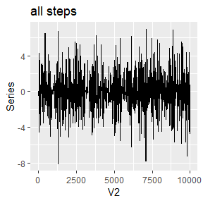

```r
DATA_last = as.data.frame(cbind(Series[9000:10000],9000:10000))
ggplot(data = DATA_0)+geom_line(aes(V2,Series))+labs(title = "all steps")
```

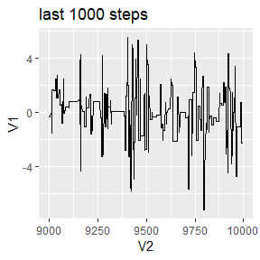

```r
ggplot(data=DATA_last)+geom_line(aes(V2,V1))+labs(title = "last 1000 steps")
```

We can see as the increase of $\sigma$, the acceptance rate becomes lower. Since 0 is the center of Laplace distribution, we can’t see obvious difference of the converge rates.

# 12-13

# Question 1

3. Use both for loops and lapply() to fit linear models to the mtcars using the formulas stored in this list: formulas <- list( mpg ~ disp, mpg ~ I(1 / disp), mpg ~ disp + wt, mpg ~ I(1 / disp) + wt ) #Answer 1

```r
data(mtcars)
formulas = list(mpg ~ disp,mpg ~ I(1 / disp),mpg ~ disp + wt,mpg ~ I(1 / disp) + wt)
# for loop
result_1 = list()
for (i in formulas){
  result_1 = c(result_1,list(lm(data=mtcars,i)))
}
#lapply
result_2 = lapply(formulas,lm,data=mtcars)
print(result_1)
```

```
## [[1]]
##
## Call:
## lm(formula = i, data = mtcars)
##
## Coefficients:
## (Intercept)         disp
##    29.59985     -0.04122
##
##
## [[2]]
##
## Call:
## lm(formula = i, data = mtcars)
##
## Coefficients:
## (Intercept)    I(1/disp)
##       10.75      1557.67
##
##
## [[3]]
##
## Call:
## lm(formula = i, data = mtcars)
##
## Coefficients:
## (Intercept)         disp           wt
##    34.96055     -0.01772     -3.35083
##
##
## [[4]]
##
## Call:
## lm(formula = i, data = mtcars)
##
## Coefficients:
## (Intercept)    I(1/disp)           wt
##      19.024     1142.560       -1.798
```

```r
print(result_2)
```

```
## [[1]]
##
## Call:
## FUN(formula = X[[i]], data = ..1)
##
## Coefficients:
## (Intercept)         disp
##    29.59985     -0.04122
##
##
## [[2]]
##
## Call:
## FUN(formula = X[[i]], data = ..1)
##
## Coefficients:
## (Intercept)    I(1/disp)
##       10.75      1557.67
##
##
## [[3]]
##
## Call:
## FUN(formula = X[[i]], data = ..1)
##
## Coefficients:
## (Intercept)         disp           wt
##    34.96055     -0.01772     -3.35083
##
##
## [[4]]
##
## Call:
## FUN(formula = X[[i]], data = ..1)
##
## Coefficients:
## (Intercept)    I(1/disp)           wt
##      19.024     1142.560       -1.798
```

# Question2

4. Fit the model mpg ~ disp to each of the bootstrap replicates of mtcars in the list below by using a for loop and lapply(). Can you do it without an anonymous function? bootstraps <- lapply(1:10, function(i) { rows <- sample(1:nrow(mtcars), rep = TRUE) mtcars[rows, ] })

# Answer2

```r
bootstraps <- lapply(1:10, function(i) {
rows <- sample(1:nrow(mtcars), rep = TRUE)
mtcars[rows, ]
})
#for loop
result1 = list()
for(i in bootstraps){
  result1 = c(result1,list(lm(data = i,mpg~disp)))
}
#lapply
result2 = lapply(bootstraps, lm,formula = mpg~disp)
print(result1)
```

```
## [[1]]
##
## Call:
## lm(formula = mpg ~ disp, data = i)
##
## Coefficients:
## (Intercept)         disp
##    29.04700     -0.04087
##
##
## [[2]]
##
## Call:
## lm(formula = mpg ~ disp, data = i)
##
## Coefficients:
## (Intercept)         disp
##    31.80115     -0.04822
##
##
## [[3]]
##
## Call:
## lm(formula = mpg ~ disp, data = i)
##
## Coefficients:
## (Intercept)         disp
##    31.23243     -0.04867
##
##
## [[4]]
##
## Call:
## lm(formula = mpg ~ disp, data = i)
##
## Coefficients:
## (Intercept)         disp
##     29.9118      -0.0414
##
##
```

[output cut: 43 more lines]

```
## lm(formula = mpg ~ disp, data = i)
##
## Coefficients:
## (Intercept)         disp
##    29.44656     -0.04126
##
##
## [[10]]
##
## Call:
## lm(formula = mpg ~ disp, data = i)
##
## Coefficients:
## (Intercept)         disp
##     30.2208      -0.0463
```

```r
print(result2)
```

```
## [[1]]
##
## Call:
## FUN(formula = ..1, data = X[[i]])
##
## Coefficients:
## (Intercept)         disp
##    29.04700     -0.04087
##
##
## [[2]]
##
## Call:
## FUN(formula = ..1, data = X[[i]])
##
## Coefficients:
## (Intercept)         disp
##    31.80115     -0.04822
##
##
## [[3]]
##
## Call:
## FUN(formula = ..1, data = X[[i]])
##
## Coefficients:
## (Intercept)         disp
##    31.23243     -0.04867
##
##
## [[4]]
##
## Call:
## FUN(formula = ..1, data = X[[i]])
##
## Coefficients:
## (Intercept)         disp
##     29.9118      -0.0414
##
##
```

[output cut: 43 more lines]

```
## FUN(formula = ..1, data = X[[i]])
##
## Coefficients:
## (Intercept)         disp
##    29.44656     -0.04126
##
##
## [[10]]
##
## Call:
## FUN(formula = ..1, data = X[[i]])
##
## Coefficients:
## (Intercept)         disp
##     30.2208      -0.0463
```

```r
#without anonymous function:
bootstraps = lapply(rep(list(mtcars),10),FUN = '[', i = sample(1:nrow(mtcars),rep=TRUE),j=1:ncol(mtcars) )
#for loop
result3 = list()
for(i in bootstraps){
  result3 = c(result3,list(lm(data = i,mpg~disp)))
}
#lapply
result4 = lapply(bootstraps, lm,formula = mpg~disp)
print(result3)
```

```
## [[1]]
##
## Call:
## lm(formula = mpg ~ disp, data = i)
##
## Coefficients:
## (Intercept)         disp
##    30.88013     -0.04623
##
##
## [[2]]
##
## Call:
## lm(formula = mpg ~ disp, data = i)
##
## Coefficients:
## (Intercept)         disp
##    30.88013     -0.04623
##
##
## [[3]]
##
## Call:
## lm(formula = mpg ~ disp, data = i)
##
## Coefficients:
## (Intercept)         disp
##    30.88013     -0.04623
##
##
## [[4]]
##
## Call:
## lm(formula = mpg ~ disp, data = i)
##
## Coefficients:
## (Intercept)         disp
##    30.88013     -0.04623
##
##
```

[output cut: 43 more lines]

```
## lm(formula = mpg ~ disp, data = i)
##
## Coefficients:
## (Intercept)         disp
##    30.88013     -0.04623
##
##
## [[10]]
##
## Call:
## lm(formula = mpg ~ disp, data = i)
##
## Coefficients:
## (Intercept)         disp
##    30.88013     -0.04623
```

```r
print(result4)
```

```
## [[1]]
##
## Call:
## FUN(formula = ..1, data = X[[i]])
##
## Coefficients:
## (Intercept)         disp
##    30.88013     -0.04623
##
##
## [[2]]
##
## Call:
## FUN(formula = ..1, data = X[[i]])
##
## Coefficients:
## (Intercept)         disp
##    30.88013     -0.04623
##
##
## [[3]]
##
## Call:
## FUN(formula = ..1, data = X[[i]])
##
## Coefficients:
## (Intercept)         disp
##    30.88013     -0.04623
##
##
## [[4]]
##
## Call:
## FUN(formula = ..1, data = X[[i]])
##
## Coefficients:
## (Intercept)         disp
##    30.88013     -0.04623
##
##
```

[output cut: 43 more lines]

```
## FUN(formula = ..1, data = X[[i]])
##
## Coefficients:
## (Intercept)         disp
##    30.88013     -0.04623
##
##
## [[10]]
##
## Call:
## FUN(formula = ..1, data = X[[i]])
##
## Coefficients:
## (Intercept)         disp
##    30.88013     -0.04623
```

# Question3

5. For each model in the previous two exercises, extract R2 using the function below. rsq <- function(mod) summary(mod)$r.squared #Answer3

```r
rsq <- function(mod) summary(mod)$r.squared
#question 1
R_1 = lapply(result_1,rsq)
R_2 = lapply(result_2,rsq)
#question 2
R1 = lapply(result1, rsq)
R2 = lapply(result2, rsq)
print(R_1)
```

```
## [[1]]
## [1] 0.7183433
##
## [[2]]
## [1] 0.8596865
##
## [[3]]
## [1] 0.7809306
##
## [[4]]
## [1] 0.8838038
```

```r
print(R_2)
```

```
## [[1]]
## [1] 0.7183433
##
## [[2]]
## [1] 0.8596865
##
## [[3]]
## [1] 0.7809306
##
## [[4]]
## [1] 0.8838038
```

```r
print(R1)
```

```
## [[1]]
## [1] 0.7214869
##
## [[2]]
## [1] 0.7981159
##
## [[3]]
## [1] 0.7656215
##
## [[4]]
## [1] 0.7463241
##
## [[5]]
## [1] 0.728403
##
## [[6]]
## [1] 0.8006626
##
## [[7]]
## [1] 0.6552779
##
## [[8]]
## [1] 0.6444812
##
## [[9]]
## [1] 0.7101062
##
## [[10]]
## [1] 0.7298773
```

```r
print(R2)
```

```
## [[1]]
## [1] 0.7214869
##
## [[2]]
## [1] 0.7981159
##
## [[3]]
## [1] 0.7656215
##
## [[4]]
## [1] 0.7463241
##
## [[5]]
## [1] 0.728403
##
## [[6]]
## [1] 0.8006626
##
## [[7]]
## [1] 0.6552779
##
## [[8]]
## [1] 0.6444812
##
## [[9]]
## [1] 0.7101062
##
## [[10]]
## [1] 0.7298773
```

# Question4

3. The following code simulates the performance of a t-test for non-normal data. Use sapply() and an anonymous function to extract the p-value from every trial. trials <- replicate( 100, t.test(rpois(10, 10), rpois(7, 10)), simplify = FALSE ) Extra challenge: get rid of the anonymous function by using [[ directly #Answer4

```r
trials <- replicate(
100,
t.test(rpois(10, 10), rpois(7, 10)),
simplify = FALSE
)
# Using anonymous function
result_anonymous = sapply(trials, function(i) i$p.value)
# Don't use anonymous fnction
result_NO_anonymous = sapply(trials,'[[',i=3)
print(result_anonymous)
```

```
##   [1] 0.283131204 0.625114584 0.957434662 0.321852959 0.489196580
##   [6] 0.294734573 0.980164665 0.648486748 0.957828242 0.106279769
##  [11] 0.085021219 0.499012234 0.402325783 0.474767616 0.711664450
##  [16] 0.064639268 0.117756870 0.126527833 0.095149487 0.016250829
##  [21] 0.500394142 0.635842438 0.450936711 0.083346500 0.432630520
##  [26] 0.151412640 0.778092729 0.608925621 0.007376517 0.128292741
##  [31] 0.413928599 0.173732877 0.891018848 0.136253983 0.625908470
##  [36] 0.022622792 0.880121374 0.158537068 0.065036368 0.568245624
##  [41] 0.258717524 0.253309016 0.376032049 0.711103288 0.551178558
##  [46] 0.681703206 0.939956376 0.282127943 0.666284309 0.431363478
##  [51] 0.787879448 0.647479758 0.131924531 0.420673818 0.074901388
##  [56] 0.921028725 0.695868733 0.717876668 0.743537710 0.930388646
##  [61] 0.992272264 0.439890487 0.855906880 0.107645275 0.793383138
##  [66] 0.589539117 0.371098585 0.706634559 0.945746170 0.300903116
##  [71] 0.795014011 0.850732072 0.356035714 0.261653828 0.839024781
##  [76] 0.853323646 0.795465073 0.180608071 0.114008229 0.616067103
##  [81] 0.196922035 0.864106601 0.759562744 0.094588528 0.054958263
##  [86] 0.247396017 0.912978507 0.581668766 0.453220430 0.088185080
##  [91] 0.942751889 0.607889867 0.660495254 0.535005989 0.602719082
##  [96] 0.926792628 0.801814706 0.875452239 0.911576046 0.464043741
```

```r
print(result_NO_anonymous)
```

```
##   [1] 0.283131204 0.625114584 0.957434662 0.321852959 0.489196580
##   [6] 0.294734573 0.980164665 0.648486748 0.957828242 0.106279769
##  [11] 0.085021219 0.499012234 0.402325783 0.474767616 0.711664450
##  [16] 0.064639268 0.117756870 0.126527833 0.095149487 0.016250829
##  [21] 0.500394142 0.635842438 0.450936711 0.083346500 0.432630520
##  [26] 0.151412640 0.778092729 0.608925621 0.007376517 0.128292741
##  [31] 0.413928599 0.173732877 0.891018848 0.136253983 0.625908470
##  [36] 0.022622792 0.880121374 0.158537068 0.065036368 0.568245624
##  [41] 0.258717524 0.253309016 0.376032049 0.711103288 0.551178558
##  [46] 0.681703206 0.939956376 0.282127943 0.666284309 0.431363478
##  [51] 0.787879448 0.647479758 0.131924531 0.420673818 0.074901388
##  [56] 0.921028725 0.695868733 0.717876668 0.743537710 0.930388646
##  [61] 0.992272264 0.439890487 0.855906880 0.107645275 0.793383138
##  [66] 0.589539117 0.371098585 0.706634559 0.945746170 0.300903116
##  [71] 0.795014011 0.850732072 0.356035714 0.261653828 0.839024781
##  [76] 0.853323646 0.795465073 0.180608071 0.114008229 0.616067103
##  [81] 0.196922035 0.864106601 0.759562744 0.094588528 0.054958263
##  [86] 0.247396017 0.912978507 0.581668766 0.453220430 0.088185080
##  [91] 0.942751889 0.607889867 0.660495254 0.535005989 0.602719082
##  [96] 0.926792628 0.801814706 0.875452239 0.911576046 0.464043741
```

# Question5

7. Implement mcsapply(), a multicore version of sapply(). Can you implement mcvapply(), a parallel version of vapply()? Why or why not? #Answer5

```r
#mcsapply
mcsapply = function(X,FUN,mc.preschedule = TRUE, mc.set.seed = TRUE,mc.silent = FALSE, mc.cores = 1L,mc.cleanup = TRUE, mc.allow.recursive = TRUE,affinity.list = NULL,...){
  temp = parallel::mclapply(X=X,FUN=FUN,mc.preschedule = mc.preschedule, mc.set.seed = mc.set.seed,mc.silent = mc.silent, mc.cores = mc.cores,mc.cleanup = mc.cleanup, mc.allow.recursive = mc.allow.recursive,affinity.list = affinity.list,... = ...)
  return(unlist(temp))
}
#mcvapply
mcvapply = function(X,FUN,mc.preschedule = TRUE, mc.set.seed = TRUE,mc.silent = FALSE, mc.cores = 1L,mc.cleanup = TRUE, mc.allow.recursive = TRUE,affinity.list = NULL,FUN.VALUE=NULL,...){
  temp = parallel::mclapply(X=X,FUN=FUN,mc.preschedule = mc.preschedule, mc.set.seed = mc.set.seed,mc.silent = mc.silent, mc.cores = mc.cores,mc.cleanup = mc.cleanup, mc.allow.recursive = mc.allow.recursive,affinity.list = affinity.list,... = ...)
  is_FUN_VALUE = sapply(temp, function(i){
    a = (mode(i)==mode(FUN.VALUE))
    b = (length(i)==length(FUN.VALUE))
    return(a&b)
  })
  if(sum(is_FUN_VALUE)==length(is_FUN_VALUE)){
    return(unlist(temp))
  }
  else{
    stop("FUN.VALUE doesn't match the shape of return values")
  }
}
```

# 12-20

# Question

You have already written an R function for Exercise 9.4 (page 277, Statistical Computing with R).

Rewrite an Rcpp function for the same task.

Compare the generated random numbers by the two functions using qqplot.

Campare the computation time of the two functions with microbenchmark. I Comments your results.

```r
library(microbenchmark)
library(Rcpp)
RF = function(L,sigma){
Series = numeric(L)
Uniform = runif(L)
k=0
for (i in 2:L){
  y = rnorm(1,Series[i-1],sigma)
  if(Uniform[i]<=exp(-abs(y)+abs(Series[i-1]))){
    Series[i] = y
    k=k+1
  }
  else{
    Series[i] = Series[i-1]
  }
}
return(Series)
}
#sourceCpp('CF.cpp')
#qqplot(RF(10000,1),CF(10000,1))
#COMP = summary(microbenchmark(RF(1000,1),CF(1000,1)))
#knitr::kable(COMP)
```

```r
# #Cpp function
# include<Rcpp.h>
# include<Rmath.h>
# include<cmath>
# using namespace Rcpp;
# //[[Rcpp::export]]
# NumericVector CF(int L, double sigma) {
#   NumericVector Series (L);
#   NumericVector Uniform = runif(L);
#   int k=0;
#   for (int i =1; i<L; i++){
#     NumericVector y = rnorm(1,Series[i-1],sigma);
#     if(Uniform[i]<=exp(-fabs(y[0])+fabs(Series[i-1]))){
#       Series[i] = y[0];
#       k=k+1;
#     }
#     else{
#       Series[i] = Series[i-1];
#     }
#   }
#   return Series;
# }
```